# Package foundations

R package development workshop  
Module 1

Forwards teaching team

## Overview

- Why write a package?
- Package structure and state
- Package development setup
- Creating a package with a working function

# Why write a package?

## Why write a package?

- You want to **generalise** code
- You want to **document** code
- You want to **test** code
- You want to **share** code
- You want to create **impact** from your work

## Script vs package

| R script | Package |
| --- | --- |
| One-off data analysis | Provides reusable components |
| Defined by `.R` extension | Defined by presence of `DESCRIPTION` file |
| `library()` calls | Imports defined in `NAMESPACE` file |
| Documentation in `#` comments | Documentation in files and `Roxygen` comments |
| Run lines or source file | Install and restart |

# Package structure and state

## Package structure

An R package is developed as a directory of source code files.

The names of files and directories must follow the specification laid out in the [Writing R Extensions](https://cran.r-project.org/doc/manuals/r-release/R-exts.html) manual - we’ll cover the main components in this workshop.

Directory tree for an example RStudio package project:

[output not shown]

## Package states

- **source**
- bundled
- binary
- installed
- in-memory

**source**

What you create and work on.

Specific directory structure with some particular components e.g., `DESCRIPTION`, an `/R` directory.

## Package states

- source
- **bundled**
- binary
- installed
- in-memory

**bundled**

Package files compressed to single `.tar.gz` file.

Also known as “source tarballs”.

Created by command line tool `R CMD build`

Unpacked it looks very like the source package.

## Package states

- source
- bundled
- **binary**
- installed
- in-memory

**binary**

Compressed copy of the package in installed form.

Also a single file.

Platform specific: `.tgz` (Mac) `.zip` (Windows).

Package developers submit a bundle to CRAN; CRAN makes and distributes binaries.

## Package states

- source
- bundled
- binary
- **installed**
- in-memory

**installed**

A directory of files in a library directory.

Any C/C++/Fortran code is in compiled form.

Help files, code and optionally data are in database form.

`install.packages()` can install from source or from a binary

## Package states

- source
- bundled
- binary
- installed
- **in-memory**

**in-memory**

If a package is installed, `library()` makes its function available by loading the package into memory and attaching it to the search path.

## Building/Installing Packages from Source

There are various reasons we may wish to build or install from source:

- Installing a CRAN package where a binary has not yet been built for the latest version.
- Installing a package from GitHub/other version-controlled source code repository, e.g.

```r
remotes::install_github("r-lib/revdepcheck")
```

- Installing our own package from the source code or building it to submit to CRAN.

If the package includes C/C++/Fortran code, we will need a suitable compiler.

# Build tools

## Linux

Debian/Ubuntu:

```bash
apt-get update
apt-get install r-base-dev
```

Fedora/RedHat: should be set up already.

## MacOS

Option 1

- [Register as an Apple developer (for free)](https://developer.apple.com/programs/register/)
  - Then, in the terminal:

    ```bash
    xcode-select --install
    ```

Option 2

- Install the current release of full [Xcode from the Mac App Store](https://itunes.apple.com/ca/app/xcode/id497799835?mt=12)
- More convenient but installs a lot you don’t need

## Windows

- Download the Rtools installer that matches your version of R from https://cran.r-project.org/bin/windows/Rtools/
- Run the installer, `Rtools.exe`, keeping the default settings.

# Package development setup

## The setup we’ll be using

We’ll be using the following tools for package development:

- RStudio: to manage and edit the package source code
  - Feel free to use any IDE you’re comfortable with
- git + GitHub: to version control the package source code
  - See https://happygitwithr.com/big-picture if unfamiliar
- **devtools** and **usethis** R packages:
  - **devtools** for functions supporting the development workflow
  - **usethis** for setup tasks
  - **devtools** depends on **usethis** package
  - Integrated with RStudio: projects, menu items/shortcuts
  - Uses system utilities internally: `R CMD` utilities bundled with R

## Follow along

For the rest of this session, follow along on your own computer to make sure you’re set up for package development and to create our example package.

## **devtools** and **usethis**

We can use **devtools** right away to check our system is setup for package development.

```r
install.packages("devtools")
```

```r
library(devtools)
```

```r
has_devel()
```

```
Your system is ready to build packages!
```

Installing **devtools** will also install **usethis**.

Check you have the latest version of **usethis** and update if not:

```r
packageVersion("usethis")
```

```
[1] '3.2.1'
```

## git sitrep

- Ask for a **sit**uation **rep**ort:

```r
usethis::git_sitrep()
```

- Check whether you have a PAT (will set up in a couple of slides if not)

  ```
  Personal access token for 'https://github.com': '<discovered>'
  ```

## Configure git

- Check in `git_sitrep` output, under `Git global (user)`, that your user name and email are defined. If not, run

```r
usethis::use_git_config(
  user.name = "YOUR NAME",     # your full name
  user.email = "name@example.com"  # email associated with GitHub account
)
```

To keep your email private:

- Go to https://github.com/settings/emails, select “Keep my email address private” and “Block command line pushes that expose my email” options
- Configure git to use the address provided of the form ID+username@users.noreply.github.com

## git vaccinate

It’s also a good idea to vaccinate. This implements best practice by adding files to your global `.gitignore`:

```r
usethis::git_vaccinate()
```

## Default branch

Set the default branch to “main” (globally)

```r
usethis::git_default_branch_configure(name = "main")
```

## Create a GitHub PAT

The **usethis** package uses personal access tokens (PAT) to communicate with GitHub.

First, make sure you’re signed into GitHub. Then run

```r
usethis::create_github_token()
```

- Add Note describing the computer or use-case (e.g. personal-macbook-pro-2021, project-xyz)
- Select expiration (recommend default 30 days)
- Check scope (default selection is fine)
- Click ‘Generate Token’
- **Important!** Copy token to clipboard, do not close window until stored (see next slide)!
- You may want to store token in a secure vault, like 1Password or BitWarden

## Store your PAT

Put your PAT into the Git credential store by running the following command and entering your copied PAT at the prompt (assume the PAT is on your clipboard).

```r
gitcreds::gitcreds_set()
```

- If you don’t have a PAT stored, will prompt you to enter: paste!
- If you do, you will be given a choice to keep/replace/see the password
  - choose as appropriate
  - if replacing, paste!
- run `git_sitrep()` again to check the PAT has been discovered

## More on usethis and GitHub creds

It is well worth reading (and following all the instructions) in the following two **usethis** vignettes:

- [usethis setup](https://usethis.r-lib.org/articles/usethis-setup.html)
- [Managing Git(Hub) Credentials](https://usethis.r-lib.org/articles/git-credentials.html)
  - See in particular the section on [ongoing PAT maintenance](https://usethis.r-lib.org/articles/git-credentials.html#ongoing-pat-maintenance)

# Create a package!

## Package name

Can only contain the characters [A-Z, a-z, 0-9, .]. Some tips:

- Unique name you can easily Google
- Avoid mixing upper and lower case
- Use abbreviations
- Add an r to make unique, e.g **stringr**
- Use wordplay, e.g. **lubridate**
- Avoid trademarked names
- Use the [**available**](https://r-lib.github.io/available/) package to check name not taken

For now, we will use **animalsounds**

## Create a package!

```r
usethis::create_package("~/Desktop/animalsounds")
```

- Be deliberate about where you create your package.
- Do not nest inside another RStudio project, R package or git repo.
- You may want to use a different path!

## `create_package()`

What happens when we run `create_package()`?

- R will create a folder called `animalsounds` which is a package and an RStudio project
- restart R in the new project
- create the some infrastructure for your package with the minimal components for a working package
- start the RStudio Build pane

## R Studio Build pane/menu

[figure not shown]

[figure not shown]

## Minimal components

**usethis** will create the minimal components of a package that we have already seen:

- `DESCRIPTION` provides metadata about your package.
- `NAMESPACE` declares the functions your package exports for external use and the external functions your package imports from other packages.
- The `/R` directory is where we will put `.R` files with function definitions.

## Auxiliary files

**usethis** also adds some auxiliary files:

- `animalsounds.Rproj` is the file that makes this directory an RStudio Project.
- `.Rbuildignore` lists files that we need but that should not be included when building the R package from source.
- `.gitignore` anticipates Git usage and ignores some standard, behind-the-scenes files created by R and RStudio.

# git and GitHub

## Use git

To make our project a git repository, or ‘repo’, on our local machine we use `usethis::use_git()`

Make your package a git repo:

```r
usethis::use_git()
```

## `use_git()` output (part 1)

```r
 ✔ Initialising Git repo
 ✔ Adding '.Rhistory', '.Rdata', '.httr-oauth', '.DS_Store' to  '.gitignore'
 There are 5 uncommitted files:
 * '.gitignore'
 * '.Rbuildignore'
 * 'DESCRIPTION'
 * 'animalsounds.Rproj'
 * 'NAMESPACE'
 Is it ok to commit them?

 1: I agree
 2: Absolutely not
 3: No way
```

Choose the affirmative option! (The exact options may vary.)

## `use_git()` output (part 2)

```r
√ Adding files
√ Commit with message 'Initial commit'
• A restart of RStudio is required to activate the Git pane
Restart now?

1: Nope
2: Definitely
3: No
```

Choose the affirmative option! (The exact options may vary.)

## Use GitHub

To create a copy on GitHub we use `usethis::use_github()`.

```r
usethis::use_github() # creates a public repo
usethis::use_github(private = TRUE) # private repo (licensing, no Pages)
```

This takes a local project, creates an associated repo on GitHub, adds it to your local repo as the “origin remote”, and makes an initial “push” to synchronize.

## `use_github()` output

```r
usethis::use_github()
```

```r
 ✔ Creating GitHub repository 'forwards/animalsounds'
 ✔ Setting remote 'origin' to 'https://github.com/forwards/animalsounds.git'
 ✔ Setting URL field in DESCRIPTION to  'https://github.com/forwards/animalsounds'
 ✔ Setting BugReports field in DESCRIPTION to  'https://github.com/forwards/animalsounds/issues'
 There is 1 uncommitted file:
 * 'DESCRIPTION'
 Is it ok to commit it?

 1: Nope
 2: For sure
 3: No way
```

Choose the affirmative option! (The exact options may vary.)

Note that you will see `<USER>/animalsounds` instead of `forwards/animalsounds`.

## Adding functions

Functions go in an `.R` file in the `/R` directory.

There’s a `usethis` helper for adding `.R` files!

```r
usethis::use_r("file_name")
```

`usethis::use_r()` adds the file extension (you don’t need to).

Use a separate `.R` file for each function or closely related set of functions, e.g.

- a top-level function and the internal functions it calls
- a family of related functions
- a summary method and its print method

## `usethis::use_r()`

Create a new R file in your package called `animal_sounds.R`

```r
usethis::use_r("animal_sounds")
```

The output includes:

```r
• Modify 'R/animal_sounds.R'
```

## Add a function

Put the following toy function into your script:

```r
animal_sounds <- function(animal, sound) {
    stopifnot(is.character(animal) & length(animal) == 1)
    stopifnot(is.character(sound) & length(sound) == 1)
    paste0("The ", animal, " goes ", sound, "!")
}
```

Don’t try to use the function yet!

## Development workflow

In a normal script, you might use:

```r
source("R/animal_sounds.R")
```

However, for building packages, we need to use the `devtools` approach.

This will ensure our function has the correct namespace and can find internal functions, functions imported by our package from other packages, etc.

## Development workflow

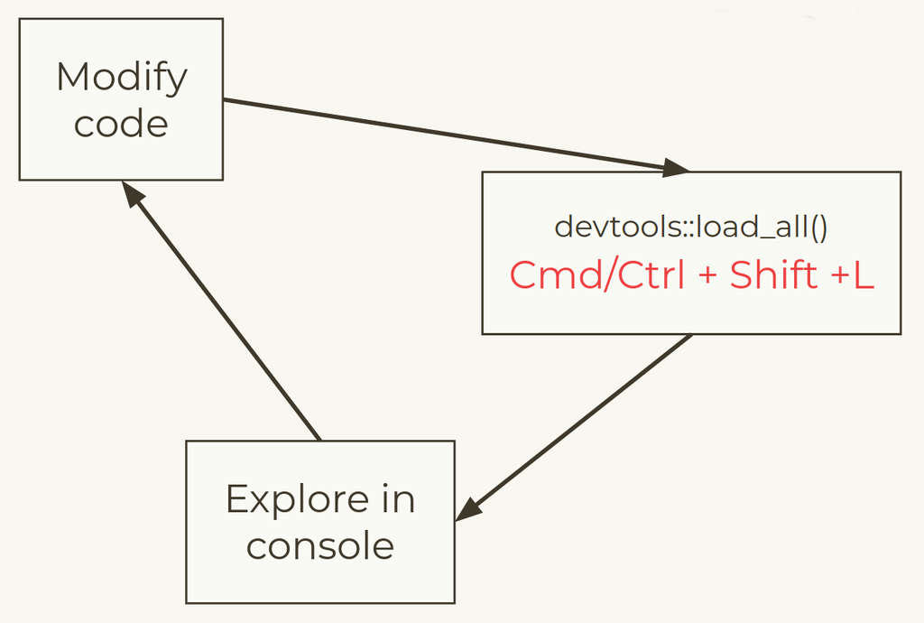

You don’t even need to save your code!

## Your turn

1. Load all with `devtools::load_all()` and try calling the `animal_sounds()` function with appropriate values for `animal` and `sound`.
2. Change some tiny thing about your function – maybe the animal “says” instead of “goes”.
3. Load all with `devtools::load_all()` and try calling the updated function to see the changed behaviour.
4. Add `animal_sounds.R` so that it is tracked by git. Make a commit with the message `Add animal_sounds()`.
5. Push all your commits from this session.

## Installing the package

`devtools::load_all()` roughly simulates what happens when a package is installed and loaded with `library()`.

To actually install the package:

- locally: `devtools::install()`
- from GitHub: `remotes::install_github("USERNAME/REPO")` or `pak::pak("USERNAME/REPO")`

# Minute cards

- [Cohort 1](https://tally.so/r/ODdWrY)
- [Cohort 2](https://tally.so/r/Zj15YB)

# End matter

## References

Wickham, H and Bryan, J, *R Packages* (2nd edn, in progress), https://r-pkgs.org.

R Core Team, *Writing R Extensions*, https://cran.r-project.org/doc/manuals/r-release/R-exts.html

## License

Licensed under a Creative Commons Attribution-NonCommercial-ShareAlike 4.0 International License ([CC BY-NC-SA 4.0](https://creativecommons.org/licenses/by-nc-sa/4.0/)).